# STAT140B Project 2

Van Nguyen

2025-04-20

# Project 2: Classification

## The Dataset

```r
math_asset <- read.csv("C:\\Users\\LapWork\\Downloads\\dataset+for+assessing+mathematics+learning+in+higher+education\\MathE dataset (4).csv",sep = ";")
```

Link to the dataset: https://archive.ics.uci.edu/dataset/1031/dataset+for+assessing+mathematics+learning+in+higher+education

The dataset contains a records of students throughout the world taking higher education math classes and whether or not the student got a question correct or not for a certain math topic.

## Examining the Data

Lets take a general looks at the data. I’ll be converting most of the columns to factors since it better represent the data.

```r
attach(math_asset)
library(tidyverse)
math_asset$Type.of.Answer <- as_factor(math_asset$Type.of.Answer)
math_asset$Student.Country <- as_factor(math_asset$Student.Country)
math_asset$Topic <- as_factor(math_asset$Topic)
math_asset$Subtopic <- as_factor(math_asset$Subtopic)
math_asset$Keywords <- as_factor(math_asset$Keywords)
math_asset$Question.Level <- as_factor(math_asset$Question.Level)
summary(math_asset)
```

```
##    Student.ID               Student.Country  Question.ID     Type.of.Answer
##  Min.   :  26.0   Portugal          :5495   Min.   :  77.0   0:5076
##  1st Qu.: 380.0   Lithuania         :1443   1st Qu.: 323.0   1:4470
##  Median : 885.0   Italy             :1358   Median : 428.0
##  Mean   : 775.4   Slovenia          : 755   Mean   : 478.9
##  3rd Qu.:1219.0   Ireland           : 300   3rd Qu.: 571.0
##  Max.   :1565.0   Russian Federation: 107   Max.   :1549.0
##                   (Other)           :  88
##   Question.Level                     Topic
##  Basic   :7844   Linear Algebra         :5726
##  Advanced:1702   Fundamental Mathematics: 818
##                  Complex Numbers        : 592
##                  Differentiation        : 579
##                  Analytic Geometry      : 358
##                  Statistics             : 340
##                  (Other)                :1133
##                                                Subtopic
##  Vector Spaces                                     :2749
##  Linear Transformations                            :2127
##  Complex Numbers                                   : 592
##  Algebraic expressions, Equations, and Inequalities: 496
##  Linear Systems                                    : 420
##  Analytic Geometry                                 : 358
##  (Other)                                           :2804
##                                        Keywords
##  Linear application,Linearity              : 443
##  Simplify expressions                      : 401
##  Subspace,Linear combination,Span          : 401
##  Linear independence,Span,Linear dependence: 399
##  Range,Kernel                              : 344
##  Matrix of a linear transformation         : 314
##  (Other)                                   :7244
```

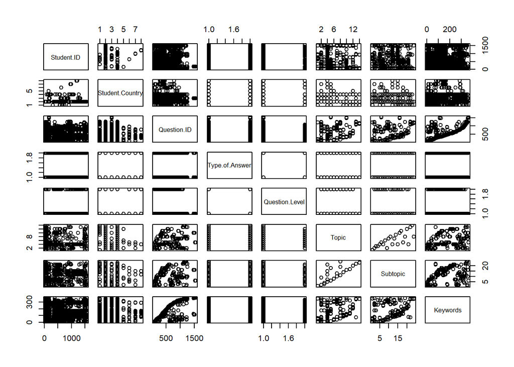

```r
plot(math_asset)
```

I am interested in the whether or not a student got an answer correct (the Type of Answer Column). There is no missing data, but the data in this data set is all categorical. Out of all the columns, StudentID and QuestionID columns stands out as information that does not feel useful since I think the the IDs of a student an question does not have an impact on a student’s performance on a question.

```r
library(car)
model <- glm(Type.of.Answer~.-Subtopic-Keywords,data=math_asset,family="binomial")
vif(model)
```

```
##                     GVIF Df GVIF^(1/(2*Df))
## Student.ID      1.474113  1        1.214131
## Student.Country 1.761837  7        1.041283
## Question.ID     1.669374  1        1.292042
## Question.Level  1.124823  1        1.060577
## Topic           3.539349 13        1.049814
```

```r
model <- glm(Type.of.Answer~.-Topic-Keywords,data=math_asset,family="binomial")
vif(model)
```

```
##                     GVIF Df GVIF^(1/(2*Df))
## Student.ID      1.664143  1        1.290017
## Student.Country 2.114585  7        1.054946
## Question.ID     1.818063  1        1.348356
## Question.Level  1.166016  1        1.079822
## Subtopic        5.413960 23        1.037399
```

```r
model <- glm(Type.of.Answer~.-Topic-Subtopic,data=math_asset,family="binomial")
vif(model)
```

```
##                      GVIF  Df GVIF^(1/(2*Df))
## Student.ID       1.724993   1        1.313390
## Student.Country  2.691228   7        1.073274
## Question.ID      3.147722   1        1.774182
## Question.Level   2.277520   1        1.509146
## Keywords        24.587151 364        1.004408
```

Looking at the VIF and the plot above, it seems that Topic, Subtopic and Keywords are aliased coefficients in a model with every predictors meaning they are highly correlated. Out of the three, choosing Topic resulted in the lowest VIF so the other two will not be chosen as predictors.

With Topic, Student Country, and Question Level as predictors, I want to model the Type of Answer/ whether the student got the answer correct or not.